# 30098870

## INTRODUCTION

Breast cancer is a type of cancer that starts in the cells of the breast. It can occur in both men and women, but it's more common in women(Mayo Clinic,2022). In this study, we will utilise unsupervised Machine Learning techniques for clustering, employing KMeans Clustering, DBScan, and Agglomerative Clustering algorithms. The supervised machine learning classification will involve the utilization of four distinct algorithms: Decision Tree, Random Forest, Logistic Regression, and Support Vector Classification (SVC).

```python
import pandas as pd
import numpy as np
import seaborn as sns
import matplotlib.pyplot as plt
```

## Part 1 - Exploratory Data Analysis

#### Viewing data set

```python
cancer = pd.read_csv("MS4S16_Dataset.csv")

#first observations
cancer.head()
```

|  | id | diagnosis | radius_mean | texture_mean | perimeter_mean | area_mean | smoothness_mean | compactness_mean | concavity_mean | concave points_mean | ... | radius_worst | texture_worst | perimeter_worst | area_worst | smoothness_worst | compactness_worst | concavity_worst | concave points_worst | symmetry_worst | fractal_dimension_worst |
| --- | --- | --- | --- | --- | --- | --- | --- | --- | --- | --- | --- | --- | --- | --- | --- | --- | --- | --- | --- | --- | --- |
| 0 | 842302.0 | M | 17.99 | 10.38 | 122.80 | 1001.0 | 0.11840 | 0.27760 | 0.3001 | 0.14710 | ... | 25.38 | 17.33 | 184.60 | 2019.0 | 0.1622 | 0.6656 | 0.7119 | 0.2654 | 0.4601 | 0.11890 |
| 1 | 842517.0 | M | 20.57 | 17.77 | 132.90 | 1326.0 | 0.08474 | 0.07864 | 0.0869 | 0.07017 | ... | 24.99 | 23.41 | 158.80 | 1956.0 | 0.1238 | 0.1866 | 0.2416 | 0.1860 | 0.2750 | 0.08902 |
| 2 | 84300903.0 | M | 19.69 | 21.25 | 130.00 | 1203.0 | 0.10960 | 0.15990 | 0.1974 | 0.12790 | ... | 23.57 | 25.53 | 152.50 | 1709.0 | 0.1444 | 0.4245 | 0.4504 | 0.2430 | 0.3613 | 0.08758 |
| 3 | 84348301.0 | M | 11.42 | 20.38 | 77.58 | 386.1 | 0.14250 | 0.28390 | 0.2414 | 0.10520 | ... | 14.91 | 26.50 | 98.87 | 567.7 | 0.2098 | 0.8663 | 0.6869 | 0.2575 | 0.6638 | 0.17300 |
| 4 | 84358402.0 | M | 20.29 | 14.34 | 135.10 | 1297.0 | 0.10030 | 0.13280 | 0.1980 | 0.10430 | ... | 22.54 | 16.67 | 152.20 | 1575.0 | 0.1374 | 0.2050 | 0.4000 | 0.1625 | 0.2364 | 0.07678 |

5 rows × 32 columns

```python
#buttom five observations
cancer.tail()
```

|  | id | diagnosis | radius_mean | texture_mean | perimeter_mean | area_mean | smoothness_mean | compactness_mean | concavity_mean | concave points_mean | ... | radius_worst | texture_worst | perimeter_worst | area_worst | smoothness_worst | compactness_worst | concavity_worst | concave points_worst | symmetry_worst | fractal_dimension_worst |
| --- | --- | --- | --- | --- | --- | --- | --- | --- | --- | --- | --- | --- | --- | --- | --- | --- | --- | --- | --- | --- | --- |
| 566 | 926682.0 | M | 20.13 | 28.25 | 131.20 | 1261.0 | 0.09780 | 0.10340 | 0.14400 | 0.09791 | ... | 23.690 | 38.25 | 155.00 | 1731.0 | 0.11660 | 0.19220 | 0.3215 | 0.1628 | 0.2572 | 0.06637 |
| 567 | 926954.0 | M | 16.60 | 28.08 | 108.30 | 858.1 | 0.08455 | 0.10230 | 0.09251 | 0.05302 | ... | 18.980 | 34.12 | 126.70 | 1124.0 | 0.11390 | 0.30940 | 0.3403 | 0.1418 | 0.2218 | 0.07820 |
| 568 | 927241.0 | M | 20.60 | 29.33 | 140.10 | 1265.0 | 0.11780 | 0.27700 | 0.35140 | 0.15200 | ... | 25.740 | 39.42 | 184.60 | 1821.0 | 0.16500 | 0.86810 | 0.9387 | 0.2650 | 0.4087 | 0.12400 |
| 569 | 92751.0 | B | 7.76 | 24.54 | 47.92 | 181.0 | 0.05263 | 0.04362 | 0.00000 | 0.00000 | ... | 9.456 | 30.37 | 59.16 | 268.6 | 0.08996 | 0.06444 | 0.0000 | 0.0000 | 0.2871 | 0.07039 |
| 570 | 92751.0 | B | 7.76 | 24.54 | 47.92 | 181.0 | 0.05263 | 0.04362 | 0.00000 | 0.00000 | ... | 9.456 | 30.37 | 59.16 | 268.6 | 0.08996 | 0.06444 | 0.0000 | 0.0000 | 0.2871 | 0.07039 |

5 rows × 32 columns

#### Summary Statistics

```python
cancer.describe()
```

|  | id | radius_mean | texture_mean | perimeter_mean | area_mean | smoothness_mean | compactness_mean | concavity_mean | concave points_mean | symmetry_mean | ... | radius_worst | texture_worst | perimeter_worst | area_worst | smoothness_worst | compactness_worst | concavity_worst | concave points_worst | symmetry_worst | fractal_dimension_worst |
| --- | --- | --- | --- | --- | --- | --- | --- | --- | --- | --- | --- | --- | --- | --- | --- | --- | --- | --- | --- | --- | --- |
| count | 5.680000e+02 | 566.000000 | 565.000000 | 567.000000 | 566.000000 | 568.000000 | 567.000000 | 567.000000 | 563.000000 | 568.000000 | ... | 558.000000 | 550.000000 | 565.000000 | 567.000000 | 562.000000 | 567.000000 | 568.000000 | 565.000000 | 567.000000 | 558.000000 |
| mean | 3.011402e+07 | 14.103267 | -241.973664 | 91.949048 | 654.942403 | 0.096312 | 0.104333 | 0.088712 | -3.500369 | 0.187402 | ... | 16.269794 | 25.735691 | 110.948035 | 897.936508 | 0.132469 | 0.254412 | 0.272125 | 0.114470 | 0.290327 | 0.084020 |
| std | 1.250894e+08 | 3.517424 | 445.216862 | 24.358029 | 352.555899 | 0.014178 | 0.052878 | 0.079739 | 59.492306 | 0.115008 | ... | 4.842370 | 6.123776 | 59.245691 | 688.231051 | 0.022865 | 0.157582 | 0.208867 | 0.065854 | 0.061907 | 0.018171 |
| min | 8.670000e+03 | 6.981000 | -999.000000 | 43.790000 | 143.500000 | 0.052630 | 0.019380 | 0.000000 | -999.000000 | 0.000700 | ... | 7.930000 | 12.020000 | 50.410000 | 185.200000 | 0.071170 | 0.027290 | 0.000000 | 0.000000 | 0.156500 | 0.055040 |
| 25% | 8.690778e+05 | 11.692500 | -999.000000 | 75.190000 | 420.300000 | 0.086290 | 0.064710 | 0.029520 | 0.019885 | 0.161900 | ... | 13.015000 | 21.222500 | 84.160000 | 515.550000 | 0.116850 | 0.147450 | 0.114475 | 0.064930 | 0.250450 | 0.071318 |
| 50% | 9.060010e+05 | 13.320000 | 17.000000 | 86.240000 | 548.750000 | 0.095895 | 0.092630 | 0.061540 | 0.033340 | 0.179200 | ... | 14.965000 | 25.455000 | 97.820000 | 686.600000 | 0.131350 | 0.214100 | 0.227450 | 0.099930 | 0.282600 | 0.079960 |
| 75% | 8.812852e+06 | 15.780000 | 21.010000 | 104.200000 | 787.050000 | 0.105325 | 0.130400 | 0.130000 | 0.073520 | 0.195700 | ... | 18.782500 | 29.705000 | 126.900000 | 1091.500000 | 0.146000 | 0.339500 | 0.383500 | 0.161300 | 0.318550 | 0.092088 |
| max | 9.113205e+08 | 28.110000 | 39.280000 | 188.500000 | 2501.000000 | 0.163400 | 0.345400 | 0.426800 | 0.201200 | 2.100000 | ... | 36.040000 | 49.540000 | 910.000000 | 10056.000000 | 0.222600 | 1.058000 | 1.252000 | 0.291000 | 0.663800 | 0.207500 |

8 rows × 31 columns

#### Viewing columns names from the Non-null count below, it can be observed that there are some missing values in the dataset

```python
cancer.info()
```

```
<class 'pandas.core.frame.DataFrame'>
RangeIndex: 571 entries, 0 to 570
Data columns (total 32 columns):
 #   Column                   Non-Null Count  Dtype
---  ------                   --------------  -----
 0   id                       568 non-null    float64
 1   diagnosis                568 non-null    object
 2   radius_mean              566 non-null    float64
 3   texture_mean             565 non-null    float64
 4   perimeter_mean           567 non-null    float64
 5   area_mean                566 non-null    float64
 6   smoothness_mean          568 non-null    float64
 7   compactness_mean         567 non-null    float64
 8   concavity_mean           567 non-null    float64
 9   concave points_mean      563 non-null    float64
```

[output cut: 24 more lines]

#### Viewing total number of missing values per column and in the whole dataset

```python
print(np.sum(cancer.isna().sum()))
cancer.isna().sum()
```

```
203
```

```
id                          3
diagnosis                   3
radius_mean                 5
texture_mean                6
perimeter_mean              4
area_mean                   5
smoothness_mean             3
compactness_mean            4
concavity_mean              4
concave points_mean         8
symmetry_mean               3
fractal_dimension_mean      4
radius_se                   6
texture_se                  8
perimeter_se                3
area_se                     6
smoothness_se               6
compactness_se              7
concavity_se                8
concave points_se           9
symmetry_se                 8
fractal_dimension_se        7
radius_worst               13
texture_worst              21
perimeter_worst             6
area_worst                  4
smoothness_worst            9
compactness_worst           4
concavity_worst             3
concave points_worst        6
symmetry_worst              4
fractal_dimension_worst    13
dtype: int64
```

```python
#replacing invalid values
cancer.replace(['?','*','-',-999,999],np.nan,inplace=True)
```

#### Viewing total number of missing values per column and in the whole dataset after replacing invalid values

```python
print(np.sum(cancer.isna().sum()))
cancer.isna().sum()
```

```
358
```

```
id                           3
diagnosis                    3
radius_mean                  5
texture_mean               151
perimeter_mean               4
area_mean                    5
smoothness_mean              3
compactness_mean             4
concavity_mean               4
concave points_mean         10
symmetry_mean                3
fractal_dimension_mean      12
radius_se                    6
texture_se                   8
perimeter_se                 3
area_se                      6
smoothness_se                6
compactness_se               7
concavity_se                 8
concave points_se            9
symmetry_se                  8
fractal_dimension_se         7
radius_worst                13
texture_worst               21
perimeter_worst              6
area_worst                   4
smoothness_worst             9
compactness_worst            4
concavity_worst              3
concave points_worst         6
symmetry_worst               4
fractal_dimension_worst     13
dtype: int64
```

#### Removing duplicates from dataset

```python
#removing duplicates
cancer.drop_duplicates(inplace=True)
```

```python
print(np.sum(cancer.isna().sum()))
cancer.isna().sum()
```

```
293
```

```
id                           1
diagnosis                    1
radius_mean                  3
texture_mean               148
perimeter_mean               2
area_mean                    3
smoothness_mean              1
compactness_mean             2
concavity_mean               2
concave points_mean          8
symmetry_mean                1
fractal_dimension_mean      10
radius_se                    4
texture_se                   6
perimeter_se                 1
area_se                      4
smoothness_se                4
compactness_se               5
concavity_se                 6
concave points_se            7
symmetry_se                  6
fractal_dimension_se         5
radius_worst                11
texture_worst               19
perimeter_worst              4
area_worst                   2
smoothness_worst             7
compactness_worst            2
concavity_worst              1
concave points_worst         4
symmetry_worst               2
fractal_dimension_worst     11
dtype: int64
```

#### Removing all rows with NaN

```python
cancer.dropna(how='all',inplace=True)
```

#### Dropping ID column

```python
cancer.drop('id',axis=1,inplace=True)
cancer.head()
```

|  | diagnosis | radius_mean | texture_mean | perimeter_mean | area_mean | smoothness_mean | compactness_mean | concavity_mean | concave points_mean | symmetry_mean | ... | radius_worst | texture_worst | perimeter_worst | area_worst | smoothness_worst | compactness_worst | concavity_worst | concave points_worst | symmetry_worst | fractal_dimension_worst |
| --- | --- | --- | --- | --- | --- | --- | --- | --- | --- | --- | --- | --- | --- | --- | --- | --- | --- | --- | --- | --- | --- |
| 0 | M | 17.99 | 10.38 | 122.80 | 1001.0 | 0.11840 | 0.27760 | 0.3001 | 0.14710 | 0.2419 | ... | 25.38 | 17.33 | 184.60 | 2019.0 | 0.1622 | 0.6656 | 0.7119 | 0.2654 | 0.4601 | 0.11890 |
| 1 | M | 20.57 | 17.77 | 132.90 | 1326.0 | 0.08474 | 0.07864 | 0.0869 | 0.07017 | 0.1812 | ... | 24.99 | 23.41 | 158.80 | 1956.0 | 0.1238 | 0.1866 | 0.2416 | 0.1860 | 0.2750 | 0.08902 |
| 2 | M | 19.69 | 21.25 | 130.00 | 1203.0 | 0.10960 | 0.15990 | 0.1974 | 0.12790 | 0.2069 | ... | 23.57 | 25.53 | 152.50 | 1709.0 | 0.1444 | 0.4245 | 0.4504 | 0.2430 | 0.3613 | 0.08758 |
| 3 | M | 11.42 | 20.38 | 77.58 | 386.1 | 0.14250 | 0.28390 | 0.2414 | 0.10520 | 0.2597 | ... | 14.91 | 26.50 | 98.87 | 567.7 | 0.2098 | 0.8663 | 0.6869 | 0.2575 | 0.6638 | 0.17300 |
| 4 | M | 20.29 | 14.34 | 135.10 | 1297.0 | 0.10030 | 0.13280 | 0.1980 | 0.10430 | 0.1809 | ... | 22.54 | 16.67 | 152.20 | 1575.0 | 0.1374 | 0.2050 | 0.4000 | 0.1625 | 0.2364 | 0.07678 |

5 rows × 31 columns

#### Calculating with the median score of each column

```python
medians = cancer.iloc[:,1:].median()
medians
```

```
radius_mean                 13.320000
texture_mean                18.910000
perimeter_mean              86.240000
area_mean                  548.750000
smoothness_mean              0.095895
compactness_mean             0.092630
concavity_mean               0.061540
concave points_mean          0.033410
symmetry_mean                0.179200
fractal_dimension_mean       0.061550
radius_se                    0.323700
texture_se                   1.127000
perimeter_se                 2.282500
area_se                     24.440000
smoothness_se                0.006356
compactness_se               0.020435
concavity_se                 0.025860
concave points_se            0.010920
symmetry_se                  0.018730
fractal_dimension_se         0.003217
radius_worst                14.965000
texture_worst               25.445000
perimeter_worst             97.820000
area_worst                 686.600000
smoothness_worst             0.131400
compactness_worst            0.214100
concavity_worst              0.227450
concave points_worst         0.099930
symmetry_worst               0.282300
fractal_dimension_worst      0.080015
dtype: float64
```

#### Replacing the missing values with the calculated median for each column

```python
cancer.fillna(medians,inplace=True)
cancer.info()
```

```
<class 'pandas.core.frame.DataFrame'>
Index: 566 entries, 0 to 569
Data columns (total 31 columns):
 #   Column                   Non-Null Count  Dtype
---  ------                   --------------  -----
 0   diagnosis                566 non-null    object
 1   radius_mean              566 non-null    float64
 2   texture_mean             566 non-null    float64
 3   perimeter_mean           566 non-null    float64
 4   area_mean                566 non-null    float64
 5   smoothness_mean          566 non-null    float64
 6   compactness_mean         566 non-null    float64
 7   concavity_mean           566 non-null    float64
 8   concave points_mean      566 non-null    float64
 9   symmetry_mean            566 non-null    float64
```

[output cut: 23 more lines]

#### Comfirming no null values in the dataset

```python
print(np.sum(cancer.isna().sum()))
cancer.isna().sum()
```

```
0
```

```
diagnosis                  0
radius_mean                0
texture_mean               0
perimeter_mean             0
area_mean                  0
smoothness_mean            0
compactness_mean           0
concavity_mean             0
concave points_mean        0
symmetry_mean              0
fractal_dimension_mean     0
radius_se                  0
texture_se                 0
perimeter_se               0
area_se                    0
smoothness_se              0
compactness_se             0
concavity_se               0
concave points_se          0
symmetry_se                0
fractal_dimension_se       0
radius_worst               0
texture_worst              0
perimeter_worst            0
area_worst                 0
smoothness_worst           0
compactness_worst          0
concavity_worst            0
concave points_worst       0
symmetry_worst             0
fractal_dimension_worst    0
dtype: int64
```

#### Finding the correlation matrixes in the dataset

```python
cancer_corr = cancer.corr(numeric_only=True,method='spearman')
cancer_corr
```

|  | radius_mean | texture_mean | perimeter_mean | area_mean | smoothness_mean | compactness_mean | concavity_mean | concave points_mean | symmetry_mean | fractal_dimension_mean | ... | radius_worst | texture_worst | perimeter_worst | area_worst | smoothness_worst | compactness_worst | concavity_worst | concave points_worst | symmetry_worst | fractal_dimension_worst |
| --- | --- | --- | --- | --- | --- | --- | --- | --- | --- | --- | --- | --- | --- | --- | --- | --- | --- | --- | --- | --- | --- |
| radius_mean | 1.000000 | 0.297752 | 0.994021 | 0.994437 | 0.143170 | 0.491618 | 0.640195 | 0.752496 | 0.117408 | -0.354226 | ... | 0.965258 | 0.292402 | 0.951554 | 0.968924 | 0.122112 | 0.487548 | 0.591351 | 0.719456 | 0.173842 | 0.040004 |
| texture_mean | 0.297752 | 1.000000 | 0.313676 | 0.309660 | 0.015267 | 0.241098 | 0.290223 | 0.258965 | 0.091654 | -0.048577 | ... | 0.324762 | 0.773640 | 0.341942 | 0.318818 | 0.099876 | 0.253018 | 0.290195 | 0.278454 | 0.124999 | 0.094786 |
| perimeter_mean | 0.994021 | 0.313676 | 1.000000 | 0.993397 | 0.179369 | 0.539625 | 0.678123 | 0.782209 | 0.148939 | -0.310838 | ... | 0.969411 | 0.309008 | 0.965717 | 0.972037 | 0.153629 | 0.531370 | 0.628882 | 0.751366 | 0.197974 | 0.083553 |
| area_mean | 0.994437 | 0.309660 | 0.993397 | 1.000000 | 0.134206 | 0.486096 | 0.639134 | 0.749111 | 0.116973 | -0.360018 | ... | 0.966582 | 0.304225 | 0.952519 | 0.970814 | 0.118917 | 0.484210 | 0.591600 | 0.718347 | 0.172718 | 0.035975 |
| smoothness_mean | 0.143170 | 0.015267 | 0.179369 | 0.134206 | 1.000000 | 0.678335 | 0.518251 | 0.558306 | 0.543026 | 0.574098 | ... | 0.198727 | 0.071203 | 0.215805 | 0.192656 | 0.788058 | 0.479916 | 0.427905 | 0.493277 | 0.394624 | 0.513224 |
| compactness_mean | 0.491618 | 0.241098 | 0.539625 | 0.486096 | 0.678335 | 1.000000 | 0.896522 | 0.838432 | 0.554474 | 0.484410 | ... | 0.537745 | 0.251576 | 0.574109 | 0.526893 | 0.573317 | 0.900970 | 0.837712 | 0.821977 | 0.454450 | 0.688167 |
| concavity_mean | 0.640195 | 0.290223 | 0.678123 | 0.639134 | 0.518251 | 0.896522 | 1.000000 | 0.920041 | 0.449128 | 0.249655 | ... | 0.672741 | 0.325569 | 0.703884 | 0.670641 | 0.488535 | 0.849451 | 0.938807 | 0.905343 | 0.385332 | 0.541613 |
| concave points_mean | 0.752496 | 0.258965 | 0.782209 | 0.749111 | 0.558306 | 0.838432 | 0.920041 | 1.000000 | 0.420044 | 0.124967 | ... | 0.773331 | 0.285267 | 0.788351 | 0.772886 | 0.482652 | 0.748362 | 0.819472 | 0.927971 | 0.349327 | 0.411300 |
| symmetry_mean | 0.117408 | 0.091654 | 0.148939 | 0.116973 | 0.543026 | 0.554474 | 0.449128 | 0.420044 | 1.000000 | 0.418953 | ... | 0.164675 | 0.124341 | 0.180019 | 0.155702 | 0.425488 | 0.442828 | 0.397128 | 0.399084 | 0.708598 | 0.415368 |
| fractal_dimension_mean | -0.354226 | -0.048577 | -0.310838 | -0.360018 | 0.574098 | 0.484410 | 0.249655 | 0.124967 | 0.418953 | 1.000000 | ... | -0.292195 | -0.044611 | -0.258476 | -0.305598 | 0.476189 | 0.388730 | 0.234534 | 0.129869 | 0.290578 | 0.744487 |
| radius_se | 0.548502 | 0.306454 | 0.561951 | 0.556028 | 0.336899 | 0.504206 | 0.572655 | 0.630970 | 0.335987 | -0.008915 | ... | 0.594644 | 0.259875 | 0.576283 | 0.589183 | 0.206029 | 0.335682 | 0.401926 | 0.505569 | 0.142610 | 0.109385 |
| texture_se | -0.156886 | 0.356127 | -0.141598 | -0.148301 | 0.097156 | 0.049083 | 0.046353 | 0.000275 | 0.143330 | 0.162924 | ... | -0.161163 | 0.459777 | -0.142057 | -0.163643 | -0.016574 | -0.090791 | -0.075822 | -0.100230 | -0.120607 | -0.043024 |
| perimeter_se | 0.561593 | 0.327813 | 0.582747 | 0.569360 | 0.332595 | 0.585092 | 0.646947 | 0.677612 | 0.356005 | 0.044601 | ... | 0.603309 | 0.284492 | 0.609715 | 0.596804 | 0.200792 | 0.440778 | 0.492141 | 0.571065 | 0.167576 | 0.189776 |
| area_se | 0.728761 | 0.335644 | 0.737321 | 0.735573 | 0.305806 | 0.546692 | 0.648184 | 0.724044 | 0.300459 | -0.113370 | ... | 0.765359 | 0.304462 | 0.738766 | 0.762946 | 0.201927 | 0.424922 | 0.508899 | 0.622138 | 0.168020 | 0.107249 |
| smoothness_se | -0.326394 | 0.015482 | -0.304673 | -0.323744 | 0.338265 | 0.126316 | 0.073204 | 0.021701 | 0.199881 | 0.400394 | ... | -0.314276 | -0.040915 | -0.306326 | -0.315894 | 0.366329 | -0.049812 | -0.060061 | -0.074302 | -0.072837 | 0.123798 |
| compactness_se | 0.261605 | 0.206116 | 0.306577 | 0.260143 | 0.400773 | 0.814902 | 0.756638 | 0.600797 | 0.436300 | 0.463158 | ... | 0.286556 | 0.199250 | 0.334118 | 0.275711 | 0.323359 | 0.785914 | 0.695918 | 0.590935 | 0.267877 | 0.597294 |
| concavity_se | 0.356540 | 0.232526 | 0.395712 | 0.355354 | 0.358012 | 0.772144 | 0.855275 | 0.664204 | 0.371665 | 0.341322 | ... | 0.370881 | 0.219242 | 0.415608 | 0.368427 | 0.305868 | 0.726709 | 0.806680 | 0.657952 | 0.228637 | 0.504176 |
| concave points_se | 0.402200 | 0.182996 | 0.435061 | 0.396671 | 0.440758 | 0.732236 | 0.770484 | 0.752946 | 0.384911 | 0.281697 | ... | 0.399336 | 0.141436 | 0.425043 | 0.395710 | 0.292183 | 0.582241 | 0.619447 | 0.687244 | 0.131054 | 0.360866 |
| symmetry_se | -0.242347 | -0.000022 | -0.225446 | -0.236608 | 0.147781 | 0.100463 | 0.021937 | -0.031260 | 0.378004 | 0.311869 | ... | -0.267646 | -0.109373 | -0.251319 | -0.267419 | -0.042200 | -0.080245 | -0.116560 | -0.138207 | 0.276817 | 0.016302 |
| fractal_dimension_se | -0.025100 | 0.094800 | 0.016721 | -0.023781 | 0.406694 | 0.606357 | 0.501761 | 0.358121 | 0.401698 | 0.668656 | ... | 0.004250 | 0.067873 | 0.042058 | -0.005797 | 0.319671 | 0.514012 | 0.422179 | 0.324116 | 0.177637 | 0.705785 |
| radius_worst | 0.965258 | 0.324762 | 0.969411 | 0.966582 | 0.198727 | 0.537745 | 0.672741 | 0.773331 | 0.164675 | -0.292195 | ... | 1.000000 | 0.345249 | 0.963839 | 0.980778 | 0.216963 | 0.554634 | 0.647614 | 0.767047 | 0.251976 | 0.128947 |
| texture_worst | 0.292402 | 0.773640 | 0.309008 | 0.304225 | 0.071203 | 0.251576 | 0.325569 | 0.285267 | 0.124341 | -0.044611 | ... | 0.345249 | 1.000000 | 0.370286 | 0.354201 | 0.239477 | 0.339531 | 0.380062 | 0.359868 | 0.229302 | 0.194302 |
| perimeter_worst | 0.951554 | 0.341942 | 0.965717 | 0.952519 | 0.215805 | 0.574109 | 0.703884 | 0.788351 | 0.180019 | -0.258476 | ... | 0.963839 | 0.370286 | 1.000000 | 0.965484 | 0.229259 | 0.599587 | 0.686880 | 0.788989 | 0.263876 | 0.168030 |
| area_worst | 0.968924 | 0.318818 | 0.972037 | 0.970814 | 0.192656 | 0.526893 | 0.670641 | 0.772886 | 0.155702 | -0.305598 | ... | 0.980778 | 0.354201 | 0.965484 | 1.000000 | 0.212719 | 0.544991 | 0.645694 | 0.767235 | 0.248132 | 0.117004 |
| smoothness_worst | 0.122112 | 0.099876 | 0.153629 | 0.118917 | 0.788058 | 0.573317 | 0.488535 | 0.482652 | 0.425488 | 0.476189 | ... | 0.216963 | 0.239477 | 0.229259 | 0.212719 | 1.000000 | 0.554957 | 0.518584 | 0.537162 | 0.498688 | 0.608316 |
| compactness_worst | 0.487548 | 0.253018 | 0.531370 | 0.484210 | 0.479916 | 0.900970 | 0.849451 | 0.748362 | 0.442828 | 0.388730 | ... | 0.554634 | 0.339531 | 0.599587 | 0.544991 | 0.554957 | 1.000000 | 0.913749 | 0.840024 | 0.527963 | 0.756937 |
| concavity_worst | 0.591351 | 0.290195 | 0.628882 | 0.591600 | 0.427905 | 0.837712 | 0.938807 | 0.819472 | 0.397128 | 0.234534 | ... | 0.647614 | 0.380062 | 0.686880 | 0.645694 | 0.518584 | 0.913749 | 1.000000 | 0.902098 | 0.476546 | 0.620055 |
| concave points_worst | 0.719456 | 0.278454 | 0.751366 | 0.718347 | 0.493277 | 0.821977 | 0.905343 | 0.927971 | 0.399084 | 0.129869 | ... | 0.767047 | 0.359868 | 0.788989 | 0.767235 | 0.537162 | 0.840024 | 0.902098 | 1.000000 | 0.459159 | 0.512511 |
| symmetry_worst | 0.173842 | 0.124999 | 0.197974 | 0.172718 | 0.394624 | 0.454450 | 0.385332 | 0.349327 | 0.708598 | 0.290578 | ... | 0.251976 | 0.229302 | 0.263876 | 0.248132 | 0.498688 | 0.527963 | 0.476546 | 0.459159 | 1.000000 | 0.490430 |
| fractal_dimension_worst | 0.040004 | 0.094786 | 0.083553 | 0.035975 | 0.513224 | 0.688167 | 0.541613 | 0.411300 | 0.415368 | 0.744487 | ... | 0.128947 | 0.194302 | 0.168030 | 0.117004 | 0.608316 | 0.756937 | 0.620055 | 0.512511 | 0.490430 | 1.000000 |

30 rows × 30 columns

```python
cancer_corr.drop(['perimeter_mean','concave points_mean','area_mean','concavity_mean','radius_worst','compactness_mean','smoothness_mean',
'fractal_dimension_worst','radius_se','perimeter_se','area_se','concavity_worst','concave points_worst',
'compactness_se','concave points_se','texture_worst','area_worst'],inplace=True,axis=1)

cancer_corr.drop(['perimeter_mean','concave points_mean','area_mean','concavity_mean','radius_worst','compactness_mean','smoothness_mean',
'fractal_dimension_worst','radius_se','perimeter_se','area_se','concavity_worst','concave points_worst',
'compactness_se','concave points_se','texture_worst','area_worst'],inplace=True,axis=0)
```

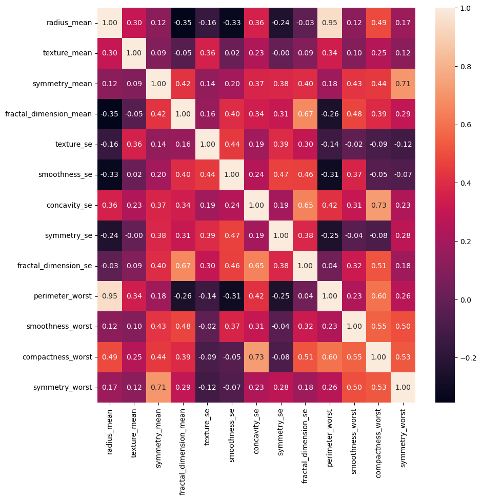

```python
plt.figure(figsize=(10,10))
sns.heatmap(cancer_corr,annot=True,fmt='.2f')
```

#### Using features from correlation to get the actual columns for the analysis and viewing the refinded dataset

```python
#using features from correlation to get columns for the analysis
list_of_cols = list(cancer_corr.columns)
list_of_cols.append('diagnosis')
```

```python
cancer = cancer[list_of_cols]
cancer
```

|  | radius_mean | texture_mean | symmetry_mean | fractal_dimension_mean | texture_se | smoothness_se | concavity_se | symmetry_se | fractal_dimension_se | perimeter_worst | smoothness_worst | compactness_worst | symmetry_worst | diagnosis |
| --- | --- | --- | --- | --- | --- | --- | --- | --- | --- | --- | --- | --- | --- | --- |
| 0 | 17.99 | 10.38 | 0.2419 | 0.07871 | 0.9053 | 0.006399 | 0.05373 | 0.03003 | 0.006193 | 184.60 | 0.16220 | 0.66560 | 0.4601 | M |
| 1 | 20.57 | 17.77 | 0.1812 | 0.05667 | 0.7339 | 0.005225 | 0.01860 | 0.01389 | 0.003532 | 158.80 | 0.12380 | 0.18660 | 0.2750 | M |
| 2 | 19.69 | 21.25 | 0.2069 | 0.05999 | 0.7869 | 0.006150 | 0.03832 | 0.02250 | 0.004571 | 152.50 | 0.14440 | 0.42450 | 0.3613 | M |
| 3 | 11.42 | 20.38 | 0.2597 | 0.09744 | 1.1560 | 0.009110 | 0.05661 | 0.05963 | 0.009208 | 98.87 | 0.20980 | 0.86630 | 0.6638 | M |
| 4 | 20.29 | 14.34 | 0.1809 | 0.05883 | 0.7813 | 0.011490 | 0.05688 | 0.01756 | 0.005115 | 152.20 | 0.13740 | 0.20500 | 0.2364 | M |
| ... | ... | ... | ... | ... | ... | ... | ... | ... | ... | ... | ... | ... | ... | ... |
| 565 | 21.56 | 22.39 | 0.1726 | 0.05623 | 1.2560 | 0.010300 | 0.05198 | 0.01114 | 0.004239 | 166.10 | 0.14100 | 0.21130 | 0.2060 | M |
| 566 | 20.13 | 28.25 | 0.1752 | 0.05533 | 2.4630 | 0.005769 | 0.03950 | 0.01898 | 0.002498 | 155.00 | 0.11660 | 0.19220 | 0.2572 | M |
| 567 | 16.60 | 28.08 | 0.1590 | 0.05648 | 1.0750 | 0.005903 | 0.04730 | 0.01318 | 0.003892 | 126.70 | 0.11390 | 0.30940 | 0.2218 | M |
| 568 | 20.60 | 29.33 | 0.2397 | 0.06155 | 1.5950 | 0.006522 | 0.07117 | 0.02324 | 0.006185 | 184.60 | 0.16500 | 0.86810 | 0.4087 | M |
| 569 | 7.76 | 24.54 | 0.1587 | 0.05884 | 1.4280 | 0.007189 | 0.00000 | 0.02676 | 0.002783 | 59.16 | 0.08996 | 0.06444 | 0.2871 | B |

566 rows × 14 columns

#### Pair plots of some features

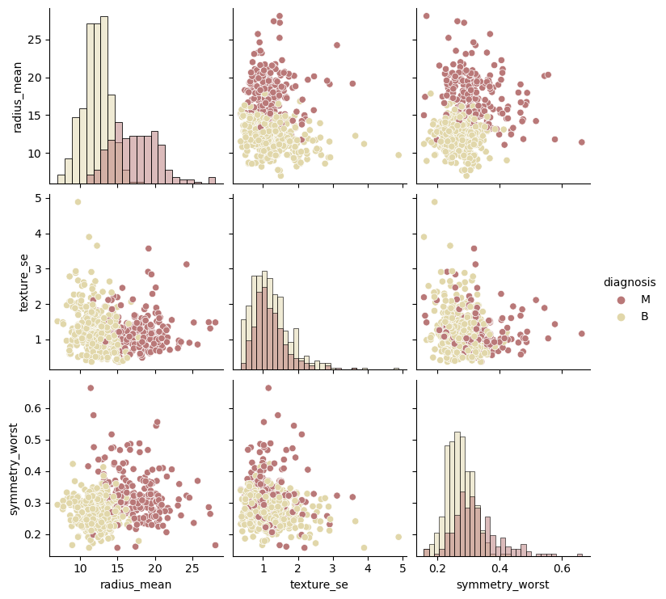

```python
sns.pairplot(cancer, x_vars=['radius_mean','texture_se','symmetry_worst'],
             y_vars=['radius_mean','texture_se','symmetry_worst'],hue='diagnosis',diag_kind='hist',
            palette='pink')
```

#### Histograms of some features in the refined dataset

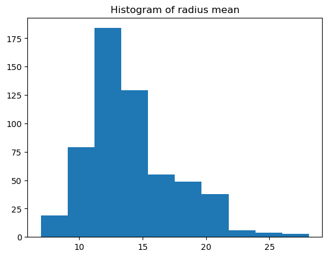

```python
plt.hist(x=cancer['radius_mean'])
plt.title('Histogram of radius mean')
plt.show()
```

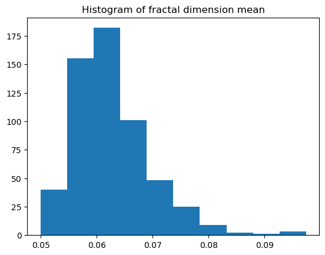

```python
plt.hist(x=cancer['fractal_dimension_mean'])
plt.title('Histogram of fractal dimension mean')
plt.show()
```

Displaying Count Plot of type of diagnosis instances

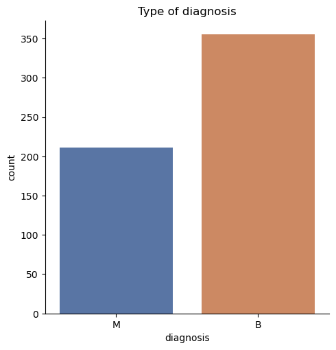

```python
g = sns.catplot(kind='count',data=cancer,x='diagnosis',palette='deep')
plt.title('Type of diagnosis')
plt.show()
```

#### Feature Scaling of refined dataset, using standard scaler because it is more tolerant to outliers...etc

```python
#using Standard Scaler
from sklearn.preprocessing import StandardScaler
scaler = StandardScaler()
```

```python
#selecting input features from the dataset
X = cancer.drop('diagnosis',axis=1)
```

```python
X
```

|  | radius_mean | texture_mean | symmetry_mean | fractal_dimension_mean | texture_se | smoothness_se | concavity_se | symmetry_se | fractal_dimension_se | perimeter_worst | smoothness_worst | compactness_worst | symmetry_worst |
| --- | --- | --- | --- | --- | --- | --- | --- | --- | --- | --- | --- | --- | --- |
| 0 | 17.99 | 10.38 | 0.2419 | 0.07871 | 0.9053 | 0.006399 | 0.05373 | 0.03003 | 0.006193 | 184.60 | 0.16220 | 0.66560 | 0.4601 |
| 1 | 20.57 | 17.77 | 0.1812 | 0.05667 | 0.7339 | 0.005225 | 0.01860 | 0.01389 | 0.003532 | 158.80 | 0.12380 | 0.18660 | 0.2750 |
| 2 | 19.69 | 21.25 | 0.2069 | 0.05999 | 0.7869 | 0.006150 | 0.03832 | 0.02250 | 0.004571 | 152.50 | 0.14440 | 0.42450 | 0.3613 |
| 3 | 11.42 | 20.38 | 0.2597 | 0.09744 | 1.1560 | 0.009110 | 0.05661 | 0.05963 | 0.009208 | 98.87 | 0.20980 | 0.86630 | 0.6638 |
| 4 | 20.29 | 14.34 | 0.1809 | 0.05883 | 0.7813 | 0.011490 | 0.05688 | 0.01756 | 0.005115 | 152.20 | 0.13740 | 0.20500 | 0.2364 |
| ... | ... | ... | ... | ... | ... | ... | ... | ... | ... | ... | ... | ... | ... |
| 565 | 21.56 | 22.39 | 0.1726 | 0.05623 | 1.2560 | 0.010300 | 0.05198 | 0.01114 | 0.004239 | 166.10 | 0.14100 | 0.21130 | 0.2060 |
| 566 | 20.13 | 28.25 | 0.1752 | 0.05533 | 2.4630 | 0.005769 | 0.03950 | 0.01898 | 0.002498 | 155.00 | 0.11660 | 0.19220 | 0.2572 |
| 567 | 16.60 | 28.08 | 0.1590 | 0.05648 | 1.0750 | 0.005903 | 0.04730 | 0.01318 | 0.003892 | 126.70 | 0.11390 | 0.30940 | 0.2218 |
| 568 | 20.60 | 29.33 | 0.2397 | 0.06155 | 1.5950 | 0.006522 | 0.07117 | 0.02324 | 0.006185 | 184.60 | 0.16500 | 0.86810 | 0.4087 |
| 569 | 7.76 | 24.54 | 0.1587 | 0.05884 | 1.4280 | 0.007189 | 0.00000 | 0.02676 | 0.002783 | 59.16 | 0.08996 | 0.06444 | 0.2871 |

566 rows × 13 columns

```python
X_scaled = scaler.fit_transform(X)
X_scaled
```

```
array([[ 1.10985104, -2.28386284,  0.47342389, ...,  1.30719176,
         2.61069355,  2.74424311],
       [ 1.84685777, -0.38092512, -0.05394972, ..., -0.38491285,
        -0.43278748, -0.24651037],
       [ 1.59547563,  0.51518087,  0.16933697, ...,  0.52283077,
         1.07878692,  1.14788199],
       ...,
       [ 0.71278152,  2.27391763, -0.24682771, ..., -0.82115856,
         0.34746193, -1.10608944],
       [ 1.85542762,  2.59579478,  0.45430986, ...,  1.43057438,
         3.89734263,  1.91374755],
       [-1.81246635,  1.36236154, -0.24943417, ..., -1.87608003,
        -1.20897045, -0.05100461]])
```

## PART 2 - CLUSTER ANALYSIS - Unsupervised Machine Learning

```python
#unsupervised learning
from sklearn.cluster import KMeans
from sklearn.metrics import silhouette_score
```

#### Finding Inertia to help with cluster identification

```python
inertia = []

for i in range(2,8):
    kmeans = KMeans(n_clusters=i,n_init='auto')
    kmeans.fit(X_scaled)
    inertia.append(kmeans.inertia_)
```

#### Plot showing Inertia Values for clusters

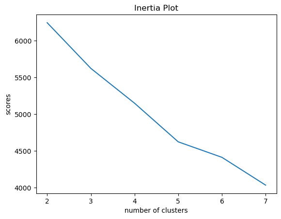

```python
#inertia values
sns.lineplot(y=inertia,x=range(2,8))
#plt.scatter(x=range(2,8),y=inertia)
plt.title('Inertia Plot')
plt.xlabel('number of clusters')
plt.ylabel('scores')
plt.show()
```

#### Finding the silhouette score to determine the number of clusters

```python
sil_score = []
for i in range(2,8):
    kmeans = KMeans(n_clusters=i,n_init='auto')
    kmeans.fit(X_scaled)
    sil_score.append(silhouette_score(X_scaled,kmeans.labels_))
```

```python
sil_score
```

```
[0.2418984985567839,
 0.19362258501850732,
 0.1608609357669621,
 0.16249656851872757,
 0.18273100392404268,
 0.19627323845947534]
```

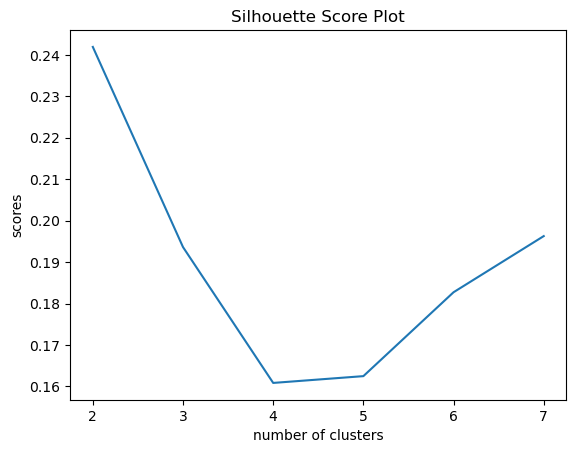

```python
sns.lineplot(y=sil_score,x=range(2,8))
plt.title('Silhouette Score Plot')
plt.xlabel('number of clusters')
plt.ylabel('scores')
plt.show()
```

#### From the above silhouette score the highest number of clusters to consider is 2.

#### Fitting the scaled data using the selected number of clusters

```python
kmeans = KMeans(n_clusters=2,n_init='auto')
```

```python
kmeans.fit(X_scaled)
```

```
KMeans(n_clusters=2, n_init='auto')
```

#### Predicted clusters from Kmeans

```python
kmeans.labels_
```

```
array([1, 0, 1, 1, 0, 1, 1, 1, 1, 1, 0, 1, 1, 0, 1, 1, 0, 1, 1, 0, 0, 0,
       1, 1, 1, 1, 1, 0, 1, 0, 1, 1, 1, 1, 1, 1, 1, 0, 0, 1, 0, 1, 1, 1,
       1, 1, 0, 1, 0, 0, 0, 0, 0, 1, 0, 0, 1, 1, 0, 0, 0, 0, 1, 0, 1, 1,
       0, 0, 1, 0, 0, 0, 1, 0, 0, 0, 0, 1, 1, 0, 0, 1, 1, 1, 0, 1, 0, 1,
       0, 0, 0, 0, 0, 0, 1, 1, 0, 0, 0, 0, 0, 0, 0, 0, 0, 1, 0, 0, 1, 0,
       0, 0, 1, 0, 0, 0, 0, 1, 1, 1, 0, 1, 1, 0, 0, 0, 1, 0, 0, 1, 0, 0,
       1, 0, 1, 0, 0, 0, 1, 0, 0, 0, 0, 0, 0, 0, 1, 0, 0, 0, 0, 1, 1, 0,
       0, 0, 1, 0, 0, 0, 0, 0, 1, 0, 1, 0, 0, 0, 1, 0, 0, 0, 1, 0, 0, 0,
       1, 1, 0, 0, 1, 1, 1, 0, 0, 0, 0, 0, 0, 0, 1, 0, 0, 1, 1, 0, 1, 0,
       1, 1, 0, 0, 1, 1, 0, 0, 0, 0, 1, 0, 1, 0, 1, 1, 1, 1, 1, 0, 1, 1,
       0, 0, 0, 1, 0, 0, 0, 0, 0, 1, 1, 0, 0, 0, 0, 0, 1, 0, 0, 1, 0, 0,
       1, 0, 0, 1, 0, 0, 1, 1, 0, 1, 0, 1, 1, 1, 1, 1, 0, 1, 0, 1, 1, 0,
       0, 0, 0, 0, 0, 1, 0, 0, 0, 0, 0, 0, 0, 1, 0, 1, 1, 0, 0, 0, 0, 0,
       0, 0, 0, 0, 0, 0, 0, 0, 0, 0, 0, 1, 0, 1, 0, 0, 0, 0, 0, 0, 0, 0,
       0, 0, 0, 0, 0, 0, 0, 1, 0, 0, 0, 0, 1, 0, 0, 0, 0, 1, 1, 1, 1, 0,
       0, 0, 1, 0, 1, 0, 1, 0, 0, 0, 1, 0, 0, 0, 0, 0, 0, 0, 1, 1, 1, 0,
       0, 0, 0, 0, 0, 0, 0, 0, 0, 0, 0, 1, 0, 0, 1, 1, 0, 1, 1, 0, 0, 1,
       0, 0, 1, 0, 0, 0, 0, 0, 0, 0, 0, 0, 1, 0, 0, 1, 1, 0, 0, 0, 0, 0,
       0, 1, 0, 0, 0, 0, 0, 0, 0, 1, 0, 0, 0, 0, 0, 0, 0, 0, 1, 0, 0, 0,
       1, 0, 0, 0, 0, 0, 0, 0, 0, 1, 0, 1, 1, 0, 1, 0, 0, 0, 0, 0, 1, 0,
       0, 0, 0, 1, 0, 0, 1, 0, 0, 0, 0, 0, 0, 0, 1, 0, 0, 1, 1, 0, 0, 0,
       1, 0, 0, 1, 1, 0, 0, 0, 0, 1, 0, 0, 0, 0, 1, 0, 0, 0, 0, 0, 1, 0,
       1, 0, 0, 0, 0, 1, 0, 0, 0, 0, 0, 1, 1, 0, 1, 0, 1, 1, 1, 0, 0, 0,
       1, 0, 0, 1, 0, 0, 0, 1, 1, 0, 0, 1, 1, 0, 0, 0, 0, 1, 0, 0, 0, 0,
       0, 0, 1, 0, 1, 0, 1, 0, 1, 0, 1, 0, 0, 0, 0, 0, 0, 0, 0, 0, 0, 0,
       0, 0, 0, 0, 0, 0, 0, 0, 1, 1, 1, 1, 1, 0, 1, 0], dtype=int32)
```

#### Plotting the Clusters

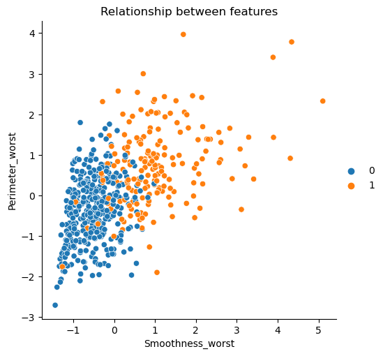

```python
#plotting clusters
sns.relplot(x = X_scaled[:,11],y =X_scaled[:,10],kind='scatter',hue=kmeans.labels_)
plt.title('Relationship between features')
plt.xlabel('Smoothness_worst')
plt.ylabel('Perimeter_worst')
plt.show()
```

#### The above scatter plot displays two features being seperated by the Kmeans label confirming the two clusters

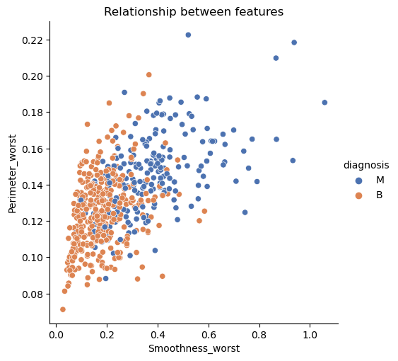

```python
sns.relplot(data = cancer,x = cancer.iloc[:,11],
            y =cancer.iloc[:,10],kind='scatter',hue='diagnosis',palette='deep')
plt.title('Relationship between features')
plt.xlabel('Smoothness_worst')
plt.ylabel('Perimeter_worst')
plt.show()
```

#### The above scatter plot displays features being seperated by the diagnosis feature of the dataset

```python
#Agglomerative clsutering
from sklearn.cluster import AgglomerativeClustering
agglomerative = AgglomerativeClustering()
```

```python
agglomerative.fit(X_scaled)
```

```
AgglomerativeClustering()
```

```python
agglomerative.labels_
```

```
array([1, 0, 0, 1, 0, 1, 0, 1, 1, 1, 0, 1, 0, 0, 1, 1, 0, 1, 0, 0, 0, 0,
       1, 0, 1, 1, 1, 0, 1, 0, 1, 1, 1, 1, 1, 1, 1, 0, 0, 0, 0, 0, 1, 1,
       0, 1, 0, 1, 0, 0, 0, 0, 0, 0, 0, 0, 0, 1, 0, 0, 0, 0, 1, 0, 1, 1,
       0, 0, 1, 0, 0, 1, 1, 0, 0, 0, 0, 1, 1, 0, 0, 1, 0, 0, 0, 0, 0, 0,
       0, 0, 0, 0, 0, 0, 1, 0, 0, 0, 0, 0, 0, 0, 0, 0, 0, 1, 0, 0, 1, 0,
       0, 0, 1, 0, 0, 0, 1, 1, 1, 0, 0, 0, 1, 0, 0, 0, 0, 0, 0, 0, 0, 0,
       0, 0, 0, 0, 0, 0, 0, 0, 0, 0, 0, 0, 0, 0, 1, 0, 0, 0, 0, 1, 1, 0,
       0, 0, 0, 0, 0, 0, 0, 0, 0, 0, 0, 0, 0, 0, 0, 0, 0, 0, 1, 0, 0, 0,
       1, 1, 0, 0, 0, 1, 0, 0, 0, 0, 0, 0, 0, 0, 1, 0, 0, 1, 1, 0, 0, 0,
       0, 1, 0, 0, 1, 1, 0, 0, 0, 0, 1, 0, 0, 0, 0, 1, 1, 1, 0, 0, 0, 0,
       0, 0, 0, 1, 0, 0, 0, 0, 0, 1, 0, 0, 0, 0, 0, 0, 0, 0, 0, 0, 0, 0,
       1, 0, 0, 1, 0, 0, 0, 1, 0, 0, 0, 0, 1, 1, 1, 0, 0, 0, 0, 0, 0, 0,
       0, 0, 0, 0, 0, 0, 0, 0, 0, 0, 0, 0, 0, 1, 0, 0, 1, 0, 0, 0, 0, 0,
       0, 0, 0, 0, 0, 0, 0, 0, 0, 0, 0, 0, 0, 1, 0, 0, 0, 0, 0, 0, 0, 0,
       0, 0, 0, 0, 0, 0, 0, 1, 0, 0, 0, 0, 1, 0, 0, 0, 0, 0, 0, 0, 1, 0,
       0, 0, 0, 0, 1, 0, 0, 0, 0, 0, 0, 0, 0, 0, 0, 0, 0, 0, 1, 1, 0, 0,
       0, 0, 0, 0, 0, 0, 0, 0, 0, 0, 0, 0, 0, 0, 0, 1, 0, 0, 0, 0, 0, 1,
       0, 0, 1, 0, 0, 0, 0, 0, 0, 0, 0, 0, 0, 0, 0, 1, 1, 0, 0, 0, 0, 0,
       0, 1, 0, 0, 0, 0, 0, 0, 0, 0, 0, 0, 0, 0, 0, 0, 0, 0, 1, 0, 0, 0,
       0, 0, 0, 0, 0, 0, 0, 0, 0, 1, 0, 0, 0, 0, 0, 0, 0, 0, 0, 0, 0, 0,
       0, 0, 0, 0, 0, 0, 0, 0, 0, 0, 0, 0, 0, 0, 0, 0, 0, 0, 0, 0, 0, 0,
       1, 0, 0, 1, 0, 0, 0, 0, 0, 0, 0, 0, 0, 0, 1, 0, 0, 0, 0, 0, 1, 0,
       0, 0, 0, 0, 0, 0, 0, 0, 0, 0, 0, 0, 0, 0, 1, 0, 0, 0, 1, 0, 0, 0,
       1, 0, 0, 1, 0, 0, 0, 0, 0, 0, 0, 0, 1, 0, 0, 0, 0, 0, 0, 0, 0, 0,
       0, 0, 0, 0, 0, 0, 0, 0, 1, 0, 1, 0, 0, 0, 0, 0, 0, 0, 0, 0, 0, 0,
       0, 0, 0, 0, 0, 0, 0, 0, 0, 1, 1, 0, 0, 0, 1, 0])
```

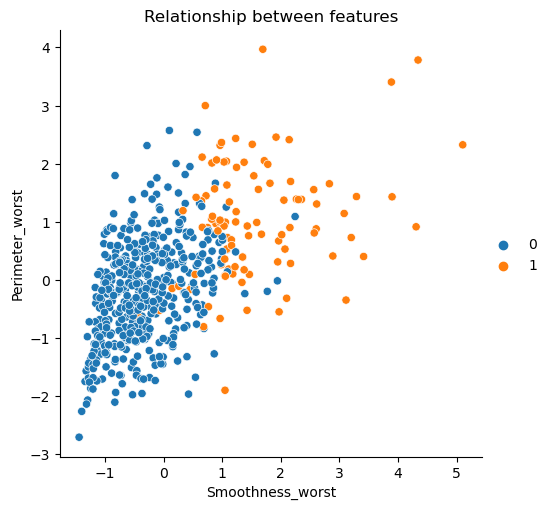

```python
sns.relplot(x = X_scaled[:,11],y =X_scaled[:,10],kind='scatter',hue=agglomerative.labels_)
plt.title('Relationship between features')
plt.xlabel('Smoothness_worst')
plt.ylabel('Perimeter_worst')
plt.show()
```

#### The above scatter plot displays two features being seperated by the agglomerative label confirming the two clusters

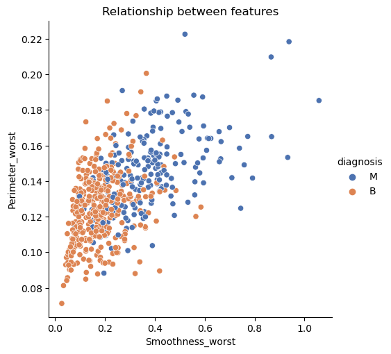

```python
sns.relplot(data = cancer,x = cancer.iloc[:,11],
            y =cancer.iloc[:,10],kind='scatter',hue='diagnosis',palette='deep')
plt.title('Relationship between features')
plt.xlabel('Smoothness_worst')
plt.ylabel('Perimeter_worst')
plt.show()
```

#### The above scatter plot displays features being seperated by the diagnosis feature of the dataset

### Dendrograms

##### visual representation confirming the number of clusters chosen

```python
#Dendrograms
from scipy.cluster.hierarchy import dendrogram,linkage
```

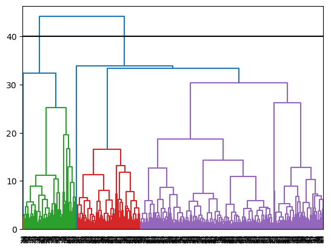

```python
dendro_plot = linkage(X_scaled,'ward')
dendrogram(dendro_plot)
plt.axhline(40, c='black')
plt.show()
```

#### The above dendograms confirms the decision to take 2 clusters

### DBSCAN

##### Finding clusters using DBSCAN

```python
from sklearn.cluster import DBSCAN
```

```python
dbscan = DBSCAN(eps=2)
```

```python
dbscan.fit(X_scaled)
```

```
DBSCAN(eps=2)
```

```python
dbscan.labels_
```

```
array([-1,  0,  0, -1,  0,  0,  0,  0,  0, -1,  0,  0, -1,  0,  0,  0,  0,
        0,  0,  0,  0,  0, -1,  0,  0, -1,  0,  0,  0,  0,  0,  0,  0,  0,
        0, -1,  0,  0, -1,  0,  0,  0, -1,  0,  0,  0,  0,  0,  0,  0,  0,
        0,  0,  0,  0,  0,  0,  0,  0,  0, -1,  0,  0, -1,  0,  0,  0,  0,
       -1,  0,  0, -1,  0,  0,  0,  0, -1,  0, -1,  0,  0,  0, -1, -1,  0,
        0,  0,  0,  0,  0,  0,  0,  0,  0,  0,  0,  0,  0,  0,  0,  0, -1,
        0,  0,  0,  0,  0,  0, -1,  0,  0,  0, -1,  0,  0,  0, -1,  0,  0,
       -1,  0,  0, -1,  0,  0,  0,  0,  0,  0,  0,  0,  0,  0,  0,  0,  0,
        0,  0, -1,  0,  0,  0,  0,  0,  0,  0, -1,  0,  0,  0,  0, -1, -1,
        0,  0,  0,  0,  0,  0,  0,  0, -1,  0,  0,  0,  0,  0,  0,  0,  0,
        0,  0,  0,  0,  0,  0, -1,  0,  0,  0, -1, -1,  0,  0,  0,  0,  0,
        0,  0,  0, -1,  0, -1,  0,  0,  0, -1,  0,  0,  0,  0,  0, -1, -1,
        0,  0,  0,  0,  0,  0,  0,  0, -1, -1, -1,  0,  0,  0,  0,  0,  0,
        0,  0,  0,  0,  0,  0,  0,  0,  0,  0,  0,  0,  0,  0,  0,  0,  0,
        0, -1,  0,  0, -1, -1,  0, -1,  0,  0, -1,  0,  0,  0,  0,  0,  0,
```

[output cut: 19 more lines]

#### The above DBSCAN shows a single cluster labeled 0 and -1 indicating noise.

## Part 3 - Supervised Machine Learning - Classification of 'M' and 'B'

```python
#Training data for classification
from sklearn.model_selection import train_test_split
```

##### Replacing diagnosis 'M' with 1 and 'B' with 0

```python
cancer['class'] = cancer['diagnosis'].apply(lambda x: 1 if x=='M' else 0)
```

```python
X= cancer.drop(['diagnosis','class'],axis=1) #Data
y = cancer['class'] #Label data
X = np.array(X).reshape(len(X),len(X.columns))
y = np.array(y).reshape(len(y),)
```

#### Spiltting the Dataset

```python
X_train, X_test, y_train, y_test = train_test_split(X,y,test_size=0.2)
```

##### Feature Scaling of Dataset

```python
#using Standard Scaler
from sklearn.preprocessing import StandardScaler
scaler = StandardScaler()
```

```python
X_train_set = scaler.fit_transform(X_train)
X_test_set = scaler.transform(X_test)
```

#### Prefered Scores being used

```python
from sklearn.metrics import accuracy_score, recall_score,precision_score, confusion_matrix
```

##### Decision Tree

```python
#Decision trees

from sklearn.tree import DecisionTreeClassifier
dec_tree = DecisionTreeClassifier()
```

##### Fitting the X-values and the Y_train set

```python
dec_tree.fit(X_train,y_train)
```

```
DecisionTreeClassifier()
```

##### Predicting the X_train values for model evaluation

```python
y_predictions = dec_tree.predict(X_train)
```

```python
print(f"Accuracy: {accuracy_score(y_train,y_predictions)}")
print(f"Recall: {recall_score(y_train,y_predictions)}")
print(f"Precision: {precision_score(y_train,y_predictions)}")
print(f"Confusion matrix:\n {confusion_matrix(y_train,y_predictions)}")
```

```
Accuracy: 1.0
Recall: 1.0
Precision: 1.0
Confusion matrix:
 [[282   0]
 [  0 170]]
```

##### Logistic Regression

```python
#logistic regression
from sklearn.linear_model import LogisticRegression
logistic = LogisticRegression(max_iter=10000)
```

```python
logistic.fit(X_train_set,y_train)
```

```
LogisticRegression(max_iter=10000)
```

```python
y_predictions = logistic.predict(X_train_set)
```

```python
print(f"Accuracy: {accuracy_score(y_train,y_predictions)}")
print(f"Recall: {recall_score(y_train,y_predictions)}")
print(f"Precision: {precision_score(y_train,y_predictions)}")
print(f"Confusion matrix:\n {confusion_matrix(y_train,y_predictions)}")
```

```
Accuracy: 0.9601769911504425
Recall: 0.9470588235294117
Precision: 0.9470588235294117
Confusion matrix:
 [[273   9]
 [  9 161]]
```

##### SVC

```python
#svc
from sklearn.svm import SVC
svc = SVC()
```

```python
svc.fit(X_train_set,y_train)
```

```
SVC()
```

```python
y_predictions = svc.predict(X_train_set)
```

```python
print(f"Accuracy: {accuracy_score(y_train,y_predictions)}")
print(f"Recall: {recall_score(y_train,y_predictions)}")
print(f"Precision: {precision_score(y_train,y_predictions)}")
print(f"Confusion matrix:\n {confusion_matrix(y_train,y_predictions)}")
```

```
Accuracy: 0.9668141592920354
Recall: 0.9529411764705882
Precision: 0.9585798816568047
Confusion matrix:
 [[275   7]
 [  8 162]]
```

##### Random Forest

```python
from sklearn.ensemble import RandomForestClassifier
forest = RandomForestClassifier()
```

```python
forest.fit(X_train,y_train)
```

```
RandomForestClassifier()
```

```python
y_predictions = forest.predict(X_train)
```

```python
print(f"Accuracy: {accuracy_score(y_train,y_predictions)}")
print(f"Recall: {recall_score(y_train,y_predictions)}")
print(f"Precision: {precision_score(y_train,y_predictions)}")
print(f"Confusion matrix:\n {confusion_matrix(y_train,y_predictions)}")
plt.show()
```

```
Accuracy: 1.0
Recall: 1.0
Precision: 1.0
Confusion matrix:
 [[282   0]
 [  0 170]]
```

##### An accuracy of 1.0 (100%) obtained for Decision Tree and Random forest over fits the Train dataset.

#### Cross Validation (CV) using the recall as scoring metric

```python
from sklearn.model_selection import cross_val_score
```

#### For Decision Tree

```python
scores = cross_val_score(dec_tree,X_train,y_train,
                        scoring='recall',
                        cv=10)
np.mean(scores)
```

```
0.9058823529411765
```

#### For Logistric Regression

```python
scores = cross_val_score(logistic,X_train_set,y_train,
                        scoring='recall',
                        cv=10)
np.mean(scores)
```

```
0.9235294117647059
```

#### For SVC

```python
scores = cross_val_score(svc,X_train_set,y_train,
                        scoring='recall',
                        cv=10)
np.mean(scores)
```

```
0.9235294117647058
```

#### For Random Forest

```python
scores = cross_val_score(forest,X_train,y_train,
                        scoring='recall',
                        cv=10)
np.mean(scores)
```

```
0.9235294117647059
```

```python
final_prediction = logistic.predict(X_test_set)
```

```python
print(f"Accuracy: {accuracy_score(y_test,final_prediction)}")
print(f"Recall: {recall_score(y_test,final_prediction)}")
print(f"Precision: {precision_score(y_test,final_prediction)}")
print(f"Confusion matrix:\n {confusion_matrix(y_test,final_prediction)}")
plt.show()
```

```
Accuracy: 0.9736842105263158
Recall: 0.9512195121951219
Precision: 0.975
Confusion matrix:
 [[72  1]
 [ 2 39]]
```

#### After running the final prediction model, the best recall score observed was 0.9512(95.12%) with accuracy of 0.97367(97.37%) and a precision of 0.975(97.5%)

## CONCLUSION

The study successfully distinguished nuclei groups as Malignant or Benign based on cell characteristics.

However, potential limitations encountered during the analysis included some models over fitting the train set data due to imbalance of the number of Malignant and Benign observation.

## ETHICAL IMPLICATION ON THE STUDY

For this study, some of the ethical implication might include ensuring adequate informed consent from patients for the use of their biological samples and clinical data, especially concerning the potential risks and benefits of participation. Patient privacy also presents an ethical consideration, necessitating the safeguarding of patient confidentiality through anonymization of data and secure storage practices to prevent unauthorized access.

## REFERENCES

Mayo Clinic(2022) $Breast$ $Cancer$ Available at: https://www.mayoclinic.org/diseases-conditions/breast-cancer/symptoms-causes/syc-20352470#:~:text=Breast%20cancer%20is%20cancer%20that,far%20more%20common%20in%20women.(Accessed: 25 January 2024)